# 01_CAE

**Convolutional Autoencoder**

By Prof. Seungchul Lee  
http://iai.postech.ac.kr/  
Industrial AI Lab at POSTECH

Table of Contents

Source

- http://www.cvc.uab.es/people/joans/slides_tensorflow/tensorflow_html/layers.html
- https://towardsdatascience.com/types-of-convolutions-in-deep-learning-717013397f4d
- https://github.com/vdumoulin/conv_arithmetic
- https://towardsdatascience.com/aligning-hand-written-digits-with-convolutional-autoencoders-99128b83af8b
- https://towardsdatascience.com/up-sampling-with-transposed-convolution-9ae4f2df52d0
- https://distill.pub/2016/deconv-checkerboard/

# 1. 2D Convolution

```
tf.nn.conv2d(input, filter, strides, padding)

    input = tensor of shape [None, input_h, input_w, input_ch]
    filter = tensor of shape [k_h, k_w, input_ch, output_ch]
    strides = [1, s_h, s_w, 1]
    padding = 'SAME'
```

- filter size
  - the field of view of the convolution.
- stride
  - the step size of the kernel when traversing the image.
- padding
  - how the border of a sample is handled.
  - A padded convolution will keep the spatial output dimensions equal to the input, whereas unpadded convolutions will crop away some of the borders if the kernel is larger than 1.
  - `'SAME'` : enable zero padding
  - `'VALID'` : disable zero padding
- input and output channels
  - A convolutional layer takes a certain number of input channels ($C$) and calculates a specific number of output channels ($D$).

**Examples**

```
input = [None, 4, 4, 1]
filter size = [3, 3, 1, 1]
strides = [1, 1, 1, 1]
padding = 'VALID'
```

[figure not shown]

```
input = [None, 5, 5, 1]
filter size = [3, 3, 1, 1]
strides = [1, 1, 1, 1]
padding = 'SAME'
```

[figure not shown]

# 2. Transposed Convolution

- The need for transposed convolutions generally arises from the desire to use a transformation going in the opposite direction of a normal convolution, i.e., from something that has the shape of the output of some convolution to something that has the shape of its input while maintaining a connectivity pattern that is compatible with said convolution. For instance, one might use such a transformation as the decoding layer of a convolutional autoencoder or to project feature maps to a higher-dimensional space.
- Some sources use the name deconvolution, which is inappropriate because it’s not a deconvolution. To make things worse deconvolutions do exists, but they’re not common in the field of deep learning.
- An actual deconvolution reverts the process of a convolution.
- Imagine inputting an image into a single convolutional layer. Now take the output, throw it into a black box and out comes your original image again. This black box does a deconvolution. It is the mathematical inverse of what a convolutional layer does.
- A transposed convolution is somewhat similar because it produces the same spatial resolution a hypothetical deconvolutional layer would. However, the actual mathematical operation that’s being performed on the values is different.
- A transposed convolutional layer carries out a regular convolution but reverts its spatial transformation.

```
tf.nn.conv2d_transpose(value, filter, output_shape, strides, padding = 'SAME')

    value = 4D tensor of shape [batch, input_h, input_w, input_ch]
    filter = tensor of shape [k_h, k_w, output_ch, input_ch]
    output_shape = [batch, output_h, output_w, output_ch]
    strides = stride of the sliding window for each dimension of the input tensor
    padding = 'SAME'
```

- `'SAME'` : enable zero padding
- `'VALID'` : disable zero padding

An image of 5x5 is fed into a convolutional layer. The stride is set to 2, the padding is deactivated and the kernel is 3x3. This results in a 2x2 image.

[figure not shown]

If we wanted to reverse this process, we’d need the inverse mathematical operation so that 9 values are generated from each pixel we input. Afterward, we traverse the output image with a stride of 2. This would be a deconvolution.

A transposed convolution does not do that. The only thing in common is it guarantees that the output will be a 5x5 image as well, while still performing a normal convolution operation. To achieve this, we need to perform some fancy padding on the input.

[figure not shown]

Transposed 2D convolution with no padding, stride of 2 and kernel of 3

It merely reconstructs the spatial resolution from before and performs a convolution. This may not be the mathematical inverse, but for Encoder-Decoder architectures, it’s still very helpful. This way we can combine the upscaling of an image with a convolution, instead of doing two separate processes.

- Another example of transposed convolution

[figure not shown]

Transposed 2D convolution with no padding, no stride and kernel of 3

**Strides and padding for transposed convolution (optional)**

- Source
  - A guide to convolution arithmetic for deep learning by Vincent Dumoulin and Francesco Visin
  - https://github.com/vdumoulin/conv_arithmetic

[figure not shown]

# 3. Examples

DeconvNet

[figure not shown]

- A transposed 2-D convolution layer upsamples feature maps.
- This layer is sometimes incorrectly known as a "deconvolution" or "deconv" layer. This layer is the transpose of convolution and does not perform deconvolution.

```python
%%html
<center><iframe src="https://www.youtube.com/embed/nTt_ajul8NY?start=725"
width="560" height="315" frameborder="0" allowfullscreen></iframe></center>
```

[video not shown]

# 4. CAE with MNIST

## 4.1. Import Library

```python
import numpy as np
import matplotlib.pyplot as plt
import tensorflow as tf
%matplotlib inline
```

## 4.2. Load MNIST Data

```python
from tensorflow.examples.tutorials.mnist import input_data
mnist = input_data.read_data_sets("MNIST_data/", one_hot=True)
```

[output not shown]

- Only use (1, 5, 6) digits to visualize latent space in 2-D

```python
train_idx = ((np.argmax(mnist.train.labels, 1) == 1) | \
             (np.argmax(mnist.train.labels, 1) == 5) | \
             (np.argmax(mnist.train.labels, 1) == 6))
test_idx = ((np.argmax(mnist.test.labels, 1) == 1) | \
            (np.argmax(mnist.test.labels, 1) == 5) | \
            (np.argmax(mnist.test.labels, 1) == 6))

train_imgs   = mnist.train.images[train_idx]
train_labels = mnist.train.labels[train_idx]
test_imgs    = mnist.test.images[test_idx]
test_labels  = mnist.test.labels[test_idx]
n_train      = train_imgs.shape[0]
n_test       = test_imgs.shape[0]

print ("The number of training images : {}, shape : {}".format(n_train, train_imgs.shape))
print ("The number of testing images : {}, shape : {}".format(n_test, test_imgs.shape))
```

```
The number of training images : 16583, shape : (16583, 784)
The number of testing images : 2985, shape : (2985, 784)
```

The following structure is implemented.

[figure not shown]

## 4.3. Define a Structure of a Convolutional Autoencoder

```python
# Input
input_h = 28
input_w = 28
input_ch = 1
# (None, 28, 28, 1)

## First convolution layer
k1_h = 3
k1_w = 3
k1_ch = 32
p1_h = 2
p1_w = 2
# (None, 14, 14, 32)

## Second convolution layer
k2_h = 3
k2_w = 3
k2_ch = 64
p2_h = 2
p2_w = 2
# (None, 7, 7, 64)

k3_h = 7
k3_w = 7
k3_ch = 2
# (None, 1, 1, 2)

dk3_h = 7
dk3_w = 7
dk3_ch = 64
# (None, 7, 7, 64)

## Deconvolution layer
dk2_h = 3
dk2_w = 3
dk2_ch = 32
s2_h = 2
s2_w = 2
# (None, 14, 14, 32)

## Deconvolution layer
dk1_h = 3
dk1_w = 3
dk1_ch = 1
s1_h = 2
s1_w = 2
# (None, 28, 28, 1)

## Output
output_h = 28
output_w = 28
output_ch = 1
```

## 4.4. Define Weights, Biases, and Placeholder

```python
weights = {
    'conv1' : tf.Variable(tf.random_normal([k1_h, k1_w, input_ch, k1_ch], stddev = 0.1)),
    'conv2' : tf.Variable(tf.random_normal([k2_h, k2_w, k1_ch, k2_ch], stddev = 0.1)),
    'conv3' : tf.Variable(tf.random_normal([k3_h, k3_w, k2_ch, k3_ch], stddev = 0.1)),
    'deconv3' : tf.Variable(tf.random_normal([dk3_h, dk3_w, dk3_ch, k3_ch], stddev = 0.1)),
    'deconv2' : tf.Variable(tf.random_normal([dk2_h, dk2_w, dk2_ch, dk3_ch], stddev = 0.1)),
    'deconv1' : tf.Variable(tf.random_normal([dk1_h, dk1_w, dk1_ch, dk2_ch], stddev = 0.1))
}

biases = {
    'conv1' : tf.Variable(tf.random_normal([k1_ch], stddev = 0.1)),
    'conv2' : tf.Variable(tf.random_normal([k2_ch], stddev = 0.1)),
    'conv3' : tf.Variable(tf.random_normal([k3_ch], stddev = 0.1)),
    'deconv3' : tf.Variable(tf.random_normal([dk3_ch], stddev = 0.1)),
    'deconv2' : tf.Variable(tf.random_normal([dk2_ch], stddev = 0.1)),
    'deconv1' : tf.Variable(tf.random_normal([dk1_ch], stddev = 0.1)),
}

x = tf.placeholder(tf.float32, [None, input_h, input_w, input_ch])
y = tf.placeholder(tf.float32, [None, output_h, output_w, output_ch])
```

## 4.5. Build a Model

```python
def encoder(x, weights, biases):
    ## First convolution layer
    conv1 = tf.nn.conv2d(x,
                         weights['conv1'],
                         strides = [1, 1, 1, 1],
                         padding = 'SAME')
    conv1 = tf.nn.relu(tf.add(conv1, biases['conv1']))
    maxp1 = tf.nn.max_pool(conv1,
                           ksize = [1, p1_h, p1_w, 1],
                           strides = [1, p1_h, p1_w, 1],
                           padding = 'VALID')

    ## Second convolution layer
    conv2 = tf.nn.conv2d(maxp1,
                         weights['conv2'],
                         strides = [1, 1, 1, 1],
                         padding = 'SAME')
    conv2 = tf.nn.relu(tf.add(conv2, biases['conv2']))
    maxp2 = tf.nn.max_pool(conv2,
                           ksize = [1, p2_h, p2_w, 1],
                           strides = [1, p2_h, p2_w, 1],
                           padding = 'VALID')

    conv3 = tf.nn.conv2d(maxp2,
                         weights['conv3'],
                         strides = [1, 1, 1, 1],
                         padding = 'VALID')
    conv3 = tf.nn.relu(tf.add(conv3, biases['conv3']))

    return conv3
```

```python
def decoder(latent, weights, biases):
    deconv3 = tf.nn.conv2d_transpose(latent,
                                     weights['deconv3'],
                                     output_shape = [tf.shape(latent)[0], 7, 7, 64],
                                     strides = [1, 1, 1, 1],
                                     padding = 'VALID')
    deconv3 = tf.nn.relu(tf.add(deconv3, biases['deconv3']))

    ## First deconvolution layer
    deconv2 = tf.nn.conv2d_transpose(deconv3,
                                     weights['deconv2'],
                                     output_shape = [tf.shape(deconv3)[0], 14, 14, 32],
                                     strides = [1, s2_h, s2_w, 1],
                                     padding = 'SAME')
    deconv2 = tf.nn.relu(tf.add(deconv2, biases['deconv2']))

    ## Second deconvolution layer
    deconv1 = tf.nn.conv2d_transpose(deconv2,
                                     weights['deconv1'],
                                     output_shape = [tf.shape(deconv2)[0], 28, 28, 1],
                                     strides = [1, s1_h, s1_w, 1],
                                     padding = 'SAME')
    deconv1 = tf.add(deconv1, biases['deconv1'])

    return deconv1
```

## 4.6. Define Loss and Optimizer

```python
LR = 0.0001

latent = encoder(x, weights, biases)
reconst = decoder(latent, weights, biases)
loss = tf.square(tf.subtract(x, reconst))
loss = tf.reduce_mean(loss)

optm = tf.train.AdamOptimizer(LR).minimize(loss)
```

## 4.7. Define Optimization Configuration and Then Optimize

```python
def train_batch_maker(batch_size):
    random_idx = np.random.randint(n_train, size = batch_size)
    return train_imgs[random_idx], train_labels[random_idx]
```

```python
def test_batch_maker(batch_size):
    random_idx = np.random.randint(n_test, size = batch_size)
    return test_imgs[random_idx], test_labels[random_idx]
```

```python
n_batch = 50
n_iter = 5000
n_prt = 250

sess = tf.Session()
init = tf.global_variables_initializer()
sess.run(init)

loss_record_train = []
loss_record_test = []
for epoch in range(n_iter):
    train_x, _ = train_batch_maker(n_batch)
    train_x = np.reshape(train_x, [-1, input_h, input_w, input_ch])
    sess.run(optm, feed_dict = {x: train_x})

    if epoch % n_prt == 0:
        test_x, _ = test_batch_maker(n_batch)
        test_x = np.reshape(test_x, [-1, input_h, input_w, input_ch])
        c1 = sess.run(loss, feed_dict = {x: train_x})
        c2 = sess.run(loss, feed_dict = {x: test_x})
        loss_record_train.append(c1)
        loss_record_test.append(c2)
        print ("Iter : {}".format(epoch))
        print ("Cost : {}".format(c1))
```

```
Iter : 0
Cost : 0.1025521457195282
Iter : 250
Cost : 0.05687396600842476
Iter : 500
Cost : 0.0436277762055397
Iter : 750
Cost : 0.045301247388124466
Iter : 1000
Cost : 0.04396513104438782
Iter : 1250
Cost : 0.042156677693128586
Iter : 1500
Cost : 0.044919148087501526
Iter : 1750
Cost : 0.04024273157119751
Iter : 2000
Cost : 0.037145502865314484
Iter : 2250
Cost : 0.039250701665878296
Iter : 2500
Cost : 0.03933577984571457
Iter : 2750
Cost : 0.03818357735872269
Iter : 3000
Cost : 0.03235900029540062
Iter : 3250
Cost : 0.038202669471502304
Iter : 3500
Cost : 0.0335979126393795
Iter : 3750
Cost : 0.04029112681746483
Iter : 4000
Cost : 0.038832321763038635
Iter : 4250
Cost : 0.03415235877037048
Iter : 4500
Cost : 0.0404871441423893
Iter : 4750
Cost : 0.03657323122024536
```

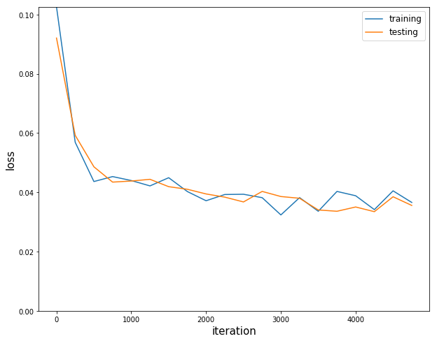

```python
plt.figure(figsize = (10,8))
plt.plot(np.arange(len(loss_record_train))*n_prt, loss_record_train, label = 'training')
plt.plot(np.arange(len(loss_record_test))*n_prt, loss_record_test, label = 'testing')
plt.xlabel('iteration', fontsize = 15)
plt.ylabel('loss', fontsize = 15)
plt.legend(fontsize = 12)
plt.ylim([0, np.max(loss_record_train)])
plt.show()
```

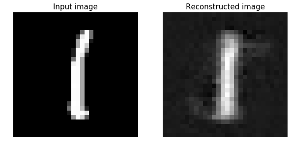

```python
test_x, _ = test_batch_maker(1)
test_x = np.reshape(test_x, [-1, input_h, input_w, input_ch])
x_reconst = sess.run(reconst, feed_dict = {x: test_x})

plt.figure(figsize = (10,8))
plt.subplot(1,2,1)
plt.imshow(test_x.reshape(28,28), 'gray')
plt.title('Input image', fontsize = 15)
plt.axis('off')
plt.subplot(1,2,2)
plt.imshow(x_reconst.reshape(28,28), 'gray')
plt.title('Reconstructed image', fontsize = 15)
plt.axis('off')
plt.show()
```

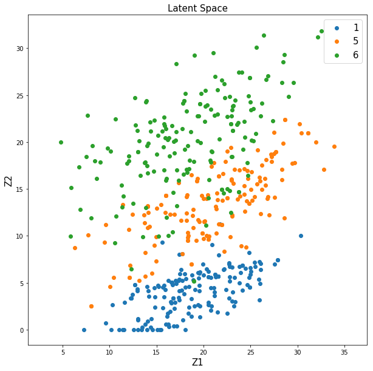

```python
test_x, test_y = test_batch_maker(500)
test_x = np.reshape(test_x, [-1, input_h, input_w, input_ch])
test_y = np.argmax(test_y, axis = 1)
test_latent = sess.run(latent, feed_dict = {x: test_x})

plt.figure(figsize=(10,10))
plt.scatter(test_latent[test_y == 1,:,:,0], test_latent[test_y == 1,:,:,1], label = '1')
plt.scatter(test_latent[test_y == 5,:,:,0], test_latent[test_y == 5,:,:,1], label = '5')
plt.scatter(test_latent[test_y == 6,:,:,0], test_latent[test_y == 6,:,:,1], label = '6')
plt.title('Latent Space', fontsize=15)
plt.xlabel('Z1', fontsize=15)
plt.ylabel('Z2', fontsize=15)
plt.legend(fontsize = 15)
plt.axis('equal')
plt.show()
```

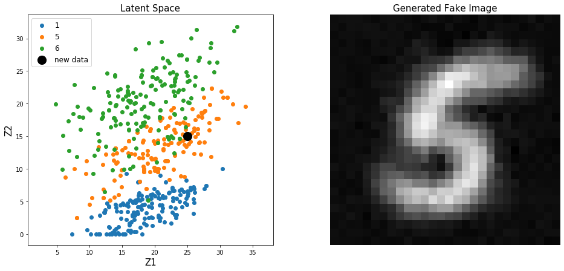

```python
new_data = np.array([[25, 15]]).reshape(-1, 1, 1, k3_ch)

latent_input = tf.placeholder(tf.float32, [None, 1, 1, k3_ch])
reconst = decoder(latent_input, weights, biases)
fake_image = sess.run(reconst, feed_dict = {latent_input: new_data})

plt.figure(figsize = (16,7))
plt.subplot(1,2,1)
plt.scatter(test_latent[test_y == 1,:,:,0], test_latent[test_y == 1,:,:,1], label = '1')
plt.scatter(test_latent[test_y == 5,:,:,0], test_latent[test_y == 5,:,:,1], label = '5')
plt.scatter(test_latent[test_y == 6,:,:,0], test_latent[test_y == 6,:,:,1], label = '6')
plt.scatter(new_data[:,:,:,0], new_data[:,:,:,1], c = 'k', marker = 'o', s = 200, label = 'new data')
plt.title('Latent Space', fontsize = 15)
plt.xlabel('Z1', fontsize = 15)
plt.ylabel('Z2', fontsize = 15)
plt.legend(loc = 2, fontsize = 12)
plt.axis('equal')
plt.subplot(1,2,2)
plt.imshow(fake_image.reshape(28,28), 'gray')
plt.title('Generated Fake Image', fontsize = 15)
plt.axis('off')
plt.show()
```

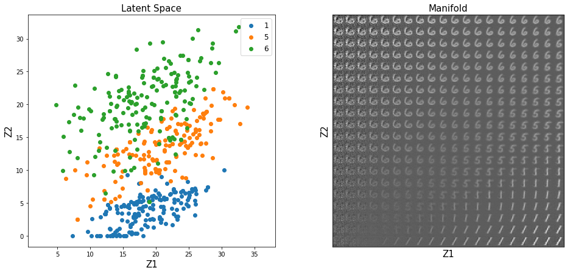

```python
# Initialize canvas
nx = 20
ny = 20
x_values = np.linspace(-5, 30, nx)
y_values = np.linspace(0, 30, ny)
canvas = np.empty((28*ny, 28*nx))

# Define placeholder
latent_input = tf.placeholder(tf.float32, [None, 1, 1, k3_ch])
reconst = decoder(latent_input, weights, biases)

for i, yi in enumerate(y_values):
        for j, xi in enumerate(x_values):
            latent_ = np.array([[xi, yi]]).reshape(-1, 1, 1, k3_ch)
            reconst_ = sess.run(reconst, feed_dict = {latent_input: latent_})
            canvas[(nx-i-1)*28:(nx-i)*28,j*28:(j+1)*28] = reconst_.reshape(28, 28)

plt.figure(figsize = (16, 7))
plt.subplot(1,2,1)
plt.scatter(test_latent[test_y == 1,:,:,0], test_latent[test_y == 1,:,:,1], label = '1')
plt.scatter(test_latent[test_y == 5,:,:,0], test_latent[test_y == 5,:,:,1], label = '5')
plt.scatter(test_latent[test_y == 6,:,:,0], test_latent[test_y == 6,:,:,1], label = '6')
plt.title('Latent Space', fontsize = 15)
plt.xlabel('Z1', fontsize = 15)
plt.ylabel('Z2', fontsize = 15)
plt.legend(fontsize = 12)
plt.axis('equal')
plt.subplot(1,2,2)
plt.imshow(canvas, 'gray')
plt.title('Manifold', fontsize = 15)
plt.xlabel('Z1', fontsize = 15)
plt.ylabel('Z2', fontsize = 15)
plt.xticks([])
plt.yticks([])
plt.show()
```

# 5. CAE Implemented with tf.layers

```python
# Input
input_h = 28
input_w = 28
input_ch = 1

## Output
output_h = 28
output_w = 28
output_ch = 1
```

```python
x = tf.placeholder(tf.float32, [None, input_h, input_w, input_ch])
y = tf.placeholder(tf.float32, [None, output_h, output_w, output_ch])
```

```python
def encoder(x):
    ## First convolution layer
    conv1 = tf.layers.conv2d(inputs = x,
                             filters = 32,
                             kernel_size = [3, 3],
                             padding = "SAME",
                             activation = tf.nn.relu)
    maxp1 = tf.layers.max_pooling2d(inputs = conv1,
                                    pool_size = [2, 2],
                                    strides = 2)

    ## Second convolution layer
    conv2 = tf.layers.conv2d(inputs = maxp1,
                             filters = 64,
                             kernel_size = [3, 3],
                             padding = "SAME",
                             activation = tf.nn.relu)
    maxp2 = tf.layers.max_pooling2d(inputs = conv2,
                                    pool_size = [2, 2],
                                    strides = 2)

    conv3 = tf.layers.conv2d(inputs = maxp2,
                             filters = 2,
                             kernel_size = [7, 7],
                             padding = "VALID",
                             use_bias = False)

    return conv3
```

```python
def decoder(latent):
    deconv3 = tf.layers.conv2d_transpose(inputs = latent,
                                         filters = 64,
                                         kernel_size = [7, 7],
                                         padding = 'VALID',
                                         activation = tf.nn.relu)

    ## First deconvolution layer
    deconv2 = tf.layers.conv2d_transpose(inputs = deconv3,
                                         filters = 32,
                                         kernel_size = [14, 14],
                                         strides = (2, 2),
                                         padding = 'SAME',
                                         activation = tf.nn.relu)

    ## Second deconvolution layer
    deconv1 = tf.layers.conv2d_transpose(inputs = deconv2,
                                         filters = 1,
                                         kernel_size = [28, 28],
                                         strides = (2, 2),
                                         padding = 'SAME')

    return deconv1
```

```python
LR = 0.0001

latent = encoder(x)
reconst = decoder(latent)
loss = tf.square(tf.subtract(x, reconst))
loss = tf.reduce_mean(loss)

optm = tf.train.AdamOptimizer(LR).minimize(loss)
```

```python
def train_batch_maker(batch_size):
    random_idx = np.random.randint(n_train, size = batch_size)
    return train_imgs[random_idx], train_labels[random_idx]

def test_batch_maker(batch_size):
    random_idx = np.random.randint(n_test, size = batch_size)
    return test_imgs[random_idx], test_labels[random_idx]
```

```python
n_batch = 50
n_iter = 5000
n_prt = 250

sess = tf.Session()
init = tf.global_variables_initializer()
sess.run(init)

loss_record_train = []
loss_record_test = []
for epoch in range(n_iter):
    train_x, _ = train_batch_maker(n_batch)
    train_x = np.reshape(train_x, [-1, input_h, input_w, input_ch])
    sess.run(optm, feed_dict = {x: train_x})

    if epoch % n_prt == 0:
        test_x, _ = test_batch_maker(n_batch)
        test_x = np.reshape(test_x, [-1, input_h, input_w, input_ch])
        c1 = sess.run(loss, feed_dict = {x: train_x})
        c2 = sess.run(loss, feed_dict = {x: test_x})
        loss_record_train.append(c1)
        loss_record_test.append(c2)
        print ("Iter : {}".format(epoch))
        print ("Cost : {}".format(c1))
```

```
Iter : 0
Cost : 0.09253013134002686
Iter : 250
Cost : 0.046988047659397125
Iter : 500
Cost : 0.03884538263082504
Iter : 750
Cost : 0.04115868732333183
Iter : 1000
Cost : 0.0378076508641243
Iter : 1250
Cost : 0.03331509232521057
Iter : 1500
Cost : 0.03450680896639824
Iter : 1750
Cost : 0.04212827607989311
Iter : 2000
Cost : 0.0352674163877964
Iter : 2250
Cost : 0.03349277377128601
Iter : 2500
Cost : 0.03413187712430954
Iter : 2750
Cost : 0.030362093821167946
Iter : 3000
Cost : 0.03311147168278694
Iter : 3250
Cost : 0.035161372274160385
Iter : 3500
Cost : 0.03162052854895592
Iter : 3750
Cost : 0.030270444229245186
Iter : 4000
Cost : 0.026799164712429047
Iter : 4250
Cost : 0.026401467621326447
Iter : 4500
Cost : 0.03401337191462517
Iter : 4750
Cost : 0.031367186456918716
```

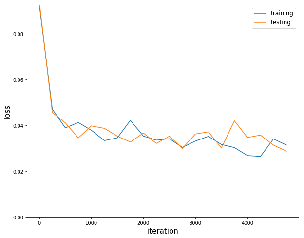

```python
plt.figure(figsize = (10,8))
plt.plot(np.arange(len(loss_record_train))*n_prt, loss_record_train, label = 'training')
plt.plot(np.arange(len(loss_record_test))*n_prt, loss_record_test, label = 'testing')
plt.xlabel('iteration', fontsize = 15)
plt.ylabel('loss', fontsize = 15)
plt.legend(fontsize = 12)
plt.ylim([0, np.max(loss_record_train)])
plt.show()
```

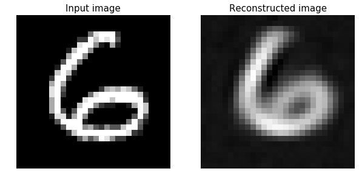

```python
test_x, _ = test_batch_maker(1)
test_x = np.reshape(test_x, [-1, input_h, input_w, input_ch])
x_reconst = sess.run(reconst, feed_dict = {x: test_x})

plt.figure(figsize = (10,8))
plt.subplot(1,2,1)
plt.imshow(test_x.reshape(28,28), 'gray')
plt.title('Input image', fontsize = 15)
plt.axis('off')
plt.subplot(1,2,2)
plt.imshow(x_reconst.reshape(28,28), 'gray')
plt.title('Reconstructed image', fontsize = 15)
plt.axis('off')
plt.show()
```

```python
%%javascript
$.getScript('https://kmahelona.github.io/ipython_notebook_goodies/ipython_notebook_toc.js')
```